# Using agents in scientific research

Isidora Araya Day

6 September 2026

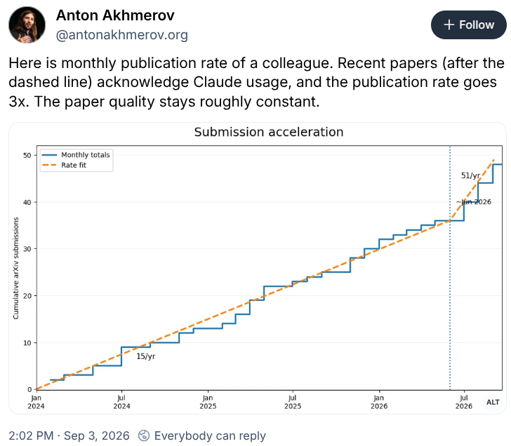

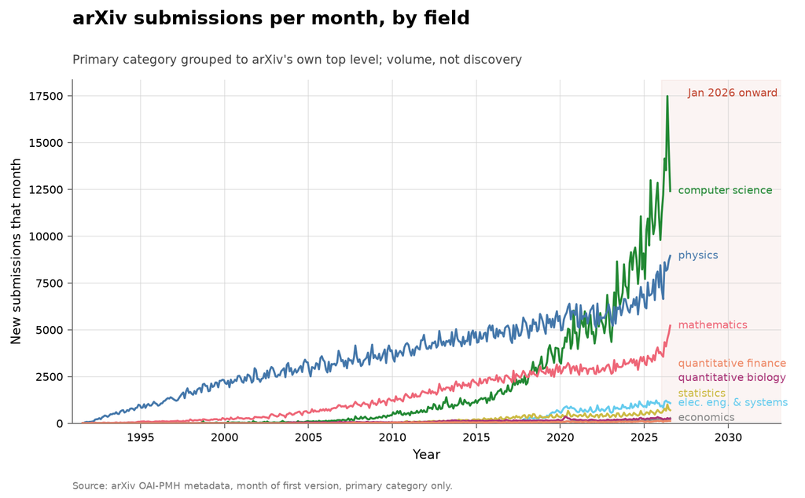

Source: [tecunningham/ai-discovery-data · output-arxiv](https://github.com/tecunningham/ai-discovery-data/tree/main/problems/output-arxiv)

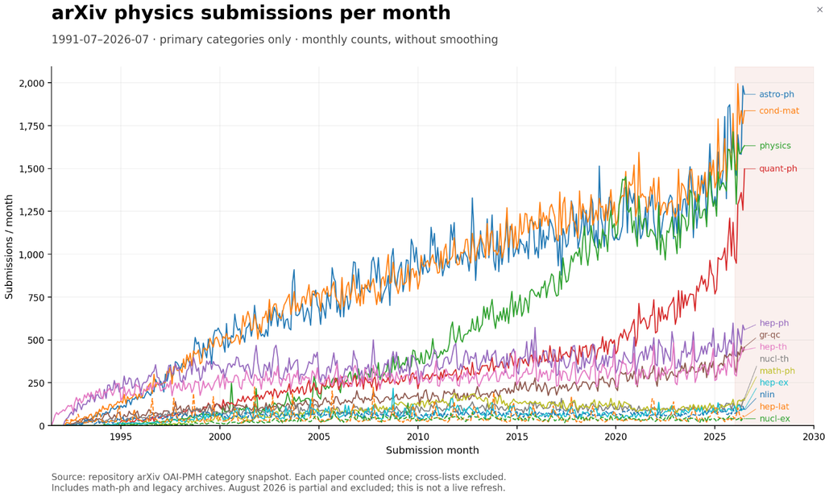

Source: [tecunningham/ai-discovery-data · output-arxiv](https://github.com/tecunningham/ai-discovery-data/tree/main/problems/output-arxiv)

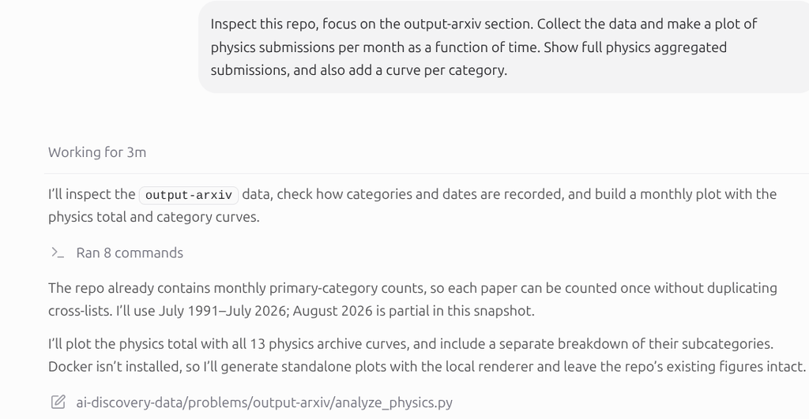

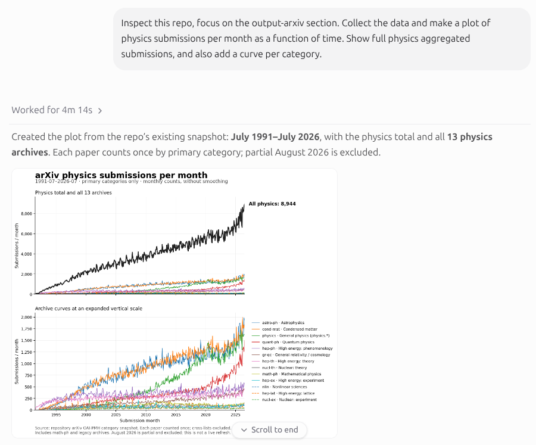

[figure not shown]

Source: [Nature](https://www.nature.com/articles/d41586-025-03967-9?utm_source=chatgpt.com)

# How do we continue to produce high quality research?

# Four ways to work with AI

1. **Chatbot** — Ask a question and use the answer.
2. **Copilot** — Write a function together.
3. **Agent** — Give it a task.
4. **Agentic workflow** — Let it run full research loops.

# Comparison between a chatbot and an agent

### Chatbot

[figure not shown]

“How can I reproduce this figure?”

1. You provide context and ask a question.
2. The chatbot suggests methods or code.
3. You run the code and bring back results.

**You carry out each step.**

### Agent

[figure not shown]

“Reproduce this figure in this project.”

1. You define the goal and checks.
2. The agent reads files, writes and runs code.
3. It checks results and revises its work.

**You review the evidence and decisions.**

# What turns an LLM into an agent?

### What it needs

- **Prompt** — Your question/instruction.
- **Context** — Papers, data, notes and code.
- **Memory** — Private notes, decisions, and progress.
- **Skills** — Instructions for recurring tasks.
- **Tools** — Access to files, code execution, and tests.

### How it works

1. **Reason** and inspect the project.
2. **Act** by using tools to carry out the work.
3. **Observe** the results and revise as needed.
4. **Record** the result and how to reproduce it.

[figure not shown]

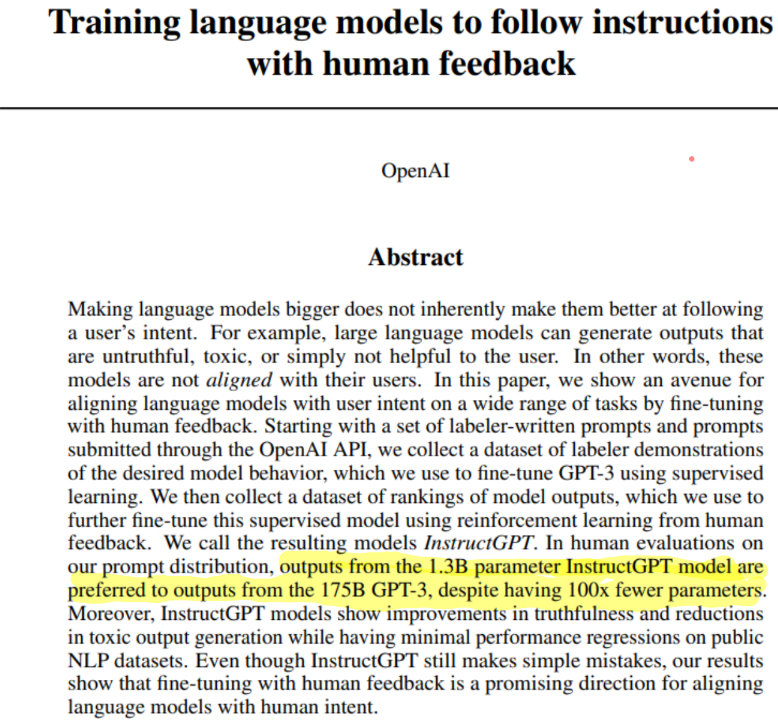

# Demo

**Tam & Kane · Probing Fermi sea topology by Andreev state transport**

[arXiv:2210.08048](https://arxiv.org/pdf/2210.08048) · Reproduce and extend a paper.

```
Create a subfolder and work there. Your job is to read arxiv: 2210.08048, write a
research project codebase that reproduces the results using tight-binding simulations,
 and extends the conductance simulation for a normal hamiltonian with random onsite disorder.
Report back with an html summary.
```

# How I structure my work

### ALL my projects live in Projects/

```
Projects/
├── spin-qubit/
├── another-project/
└── ...
```

### My workflow for every project

1. **Create** a project from my template, with its own Git repository and environment.
2. **Start Codex inside it**, with the README, notes, and a concrete task.
3. **Review** the outputs, scientific checks, and Git diff; commit the changes I accept.
4. **Resume** from saved decisions and next steps in `notes/`.

**↓ Explore the project:** project structure → working session

## 1. Organize the project

### Projects / spin-qubit

```
spin-qubit/
├── .git/
├── README.md
├── AGENTS.md
├── pyproject.toml
├── pixi.lock
├── code/
│   ├── spin_qubit_package/
│   │   ├── reusable_modules/
│   │   └── tests/
│   ├── simulations/
│   ├── results/
├── data/
├── manuscript/
├── notes/
└── slides/
```

### One reproducible research workspace

- **Package** — `spin_qubit_package/` holds reusable models, solvers, and plotting.
- **Scripts** — `simulations/` runs calculations; `results/` analyses saved data. Both import the package.
- **Tests** — Check known limits and catch regressions.
- **Environment** — `pyproject.toml` defines dependencies and tasks; `pixi.lock` pins versions.
- **Research record** — Save data, manuscript, notes, and slides together; document commands in the README and track changes with Git.

Repetitive task → Use a **skill** to set up a project structure!

## 2.Start, check, and leave a record

### Start inside the project

```bash
cd ~/Projects/spin-qubit
codex
```

```
Inspect this repo, focus on the
tight-binding implementation.
Generalize the code to ...
Verify the result by ...
```

### Process

1. **Choose a model**
2. **Give a task** — Define deliverable and checks.
3. **Ask questions** — Ask for figures, explanations.
4. **Prompt benchmarks** — Ask for tests.
5. **Ask for a record** — Write a summary.
6. **Check the diff** — If possible, inspect the Git diff.
7. **Commit** — Save the changes for later.

Prefer **focused sessions**, each with a clear goal.

## 3. Finalize the project

What I do:

- Discuss results with collaborators.
- Clean up the code and notes.
- Have my collaborators prompt the project.
- Disclose the use of AI.

The questions I still have:

- Should I read every line of code?
- Can another agent review it for me?
- How many checks are enough to trust the result?
- What results are worth publishing?

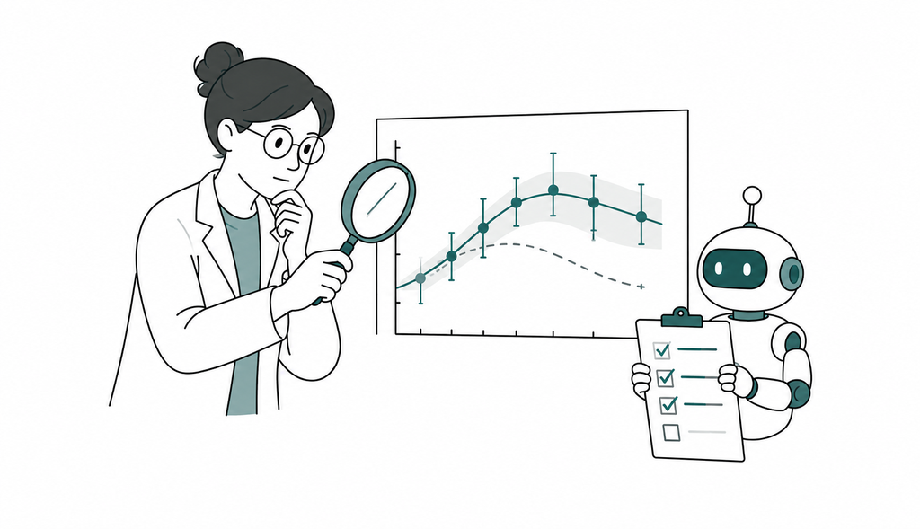

**Producing outputs is easier than knowing whether to trust them.**

# What can become an agent project?

1. **Creating a website**
2. **Filling out reimbursement forms**
3. **Scraping a website for data**
4. **Collecting literature from a chat**
5. **Reviewing someone else’s code**
6. **Launching cluster simulations**
7. **Reproducing a figure from a paper**
8. **Generalizing an algorithm**
9. **Testing an idea**

A project can be **anything with inputs and a deliverable**.

# How to get started

### Install and connect

1. **Choose an interface** — An agent app or terminal CLI.
2. **Sign in** — Pay a subscription.
3. **Prepare your tools** — Ask the agent to install Git, Python, Pixi, LaTeX, etc.
4. **Open a project folder** — Use a skill to organize it.

[figure not shown]

[OpenAI documentation ↗](https://learn.chatgpt.com/docs)

[figure not shown]

[Claude Code quickstart ↗](https://code.claude.com/docs/en/quickstart)

[figure not shown]

Terminal-Bench Science 0.1 tests whether agents can complete scientific research workflows using code and terminal tools, including analyzing data, running simulations, and fitting models.

Source: [OpenAI, GPT-6 Astra launch results](https://openai.com/index/gpt-6-astra/)

[figure not shown]

FrontierMath Tier 4 tests advanced mathematical reasoning on exceptionally difficult problems.

Source: [OpenAI, GPT-6 Astra launch results](https://openai.com/index/gpt-6-astra/)

# Things I do not have time to talk about

- How to deal with data privacy?
- How to create skills?
- How to set up remote control and launch agents on a server/cluster?
- How to document the use of AI in research?
- What are the costs of using agents in research?
- How to stay up to date with all this?

Questions?